# Lab 11: U.S. Election Map (State-level)

CMSC471: Introduction to Information Visualization (Spring 2025)

04/23/2025

In this lab, you’ll create an interactive map visualization of U.S. election results using D3.js. You’ll learn how to integrate geographic and election datasets to produce an informative visual representation.

**Learning Objectives**

- Convert geographic data into interactive visual elements using D3.js.
- Apply color scales effectively to represent election outcomes, including party results and winning margins.

## Part 1: Setup

### Project Structure

1. Locate your existing `CMSC471` folder.
2. Copy any previous lab folder and rename it to `lab11/`.
   - Open `index.html` and update the lab title to **“Lab 11: US Election Map”**.
   - Verify your `index.html`:
     - Keep only two `<div>` elements: `#vis` and `#tooltip`.
     - Delete any additional or unnecessary elements, but keep `#tooltip`.
   - Check and simplify your `css/styles.css`:
     - Remove any irrelevant or unnecessary styles.
3. **Clean up** your `js/script.js`:
   - Clear previous JavaScript code to start fresh for this lab.
4. Download and add the following files to your `data/` folder:
   - `states-albers-10m.json` ([download](https://fumeng-yang.github.io/CMSC471/handouts/states-albers-10m.json))
   - `2024_results.json` ([download](https://fumeng-yang.github.io/CMSC471/handouts/2024_results.json); prepared using Wikipedia’s 2024 election results and formatted with assistance from Claude, then manually edited)

Your folder structure should look like this:

```
lab11/
├── index.html
├── css/
│   └── styles.css
├── js/
│   └── script.js
└── data/
    ├── states-albers-10m.json
    └── 2024_results.json
```

5. **Start a local server** (choose one method):
   - **VS Code “Live Server” extension**: Click `Go Live`. It will automatically open your lab in a browser.
   - **Python 3**: Run `python -m http.server 8000` from your terminal and visit:  
     `http://localhost:8000`
6. As in previous labs, this is a **code adaptation lab**.

## Part 2: Deciding What to Copy

When creating visualizations, it’s common practice to look for relevant examples online. The [ObservableHQ gallery](https://observablehq.com/) is an excellent resource. For this lab, the map projection can be complicated—examples may use pre-projected data or include projection function.

I found two suitable examples from ObservableHQ:

- **Example 1**: [Zoom to Bounding Box](https://observablehq.com/@d3/zoom-to-bounding-box)

[figure not shown]

- **Example 2**: [U.S. State Capitals](https://observablehq.com/@d3/u-s-state-capitals)

[figure not shown]

Since **Example 1** provides clearer and more understandable code, we’ll use it as our starting point for this lab.

### Loading Data

If you scroll down Example 1, you’ll notice it loads map data into a variable named `us`. Because our visualization uses D3.js, we’ll need to adapt the data-loading approach slightly.

[figure not shown]

Example data loading

In this lab, you’ll use JavaScript’s modern asynchronous features (`async/await`) to simplify data loading. The keyword `async` marks a function as asynchronous, indicating that it handles operations like loading data or reading files, which require time. Using `await` makes your code easier to read compared to nested `.then()` calls.

Here’s our adapted code for loading data:

[figure not shown]

Example data loading

```javascript
// Function to create our visualization (placeholder for now)
function createVis(us, election_data) {
    // We'll build our visualization here
}

// Asynchronous initialization function
async function init() {
    try {
        // Load geographic (map) data
        let us = await d3.json("./data/states-albers-10m.json");

        // Load election results data
        let election_data = await d3.json("./data/2024_results.json");

        // Verify the loaded data in the console
        console.log('Map data:', us);
        console.log('Election data:', election_data);

        // Pass loaded data to visualization function
        createVis(us, election_data);
    } catch (error) {
        // Catch and report errors clearly
        console.error('Error loading data:', error);
    }
}

// Trigger data loading and visualization when the window loads
window.addEventListener('load', init);
```

> **Notes:** `try-catch` improves error handling, clearly logging any issues that occur when loading data.

### createVis()

Let’s return to Example 1 and start building our `createVis()` function.

#### Step 1: Set Up the SVG

Start by **copying the first few blocks of code**. However, since we already have a `<div id="vis">` in our `index.html`, we **replace**:

```javascript
const svg = d3.create("svg")
```

with:

```javascript
const svg = d3.select("#vis").append("svg")
```

You can **temporarily comment out** the zoom block and the `reset` line (we’ll revisit them later):

```javascript
// const zoom = ...
// ...
// ...

// .on("click", reset)
```

These parts are related to interactions like zooming and resetting, which we may not need immediately.

[figure not shown]

Copy the first few blocks

We comment out `clicked` to avoid another defined function.

#### Step 2: Understand `topojson.feature(...)`

Next, you’ll encounter this line:

```javascript
.data(topojson.feature(us, us.objects.states))
```

This line looks a little mysterious—but don’t worry. It’s transforming **TopoJSON** data (what we loaded) into **GeoJSON**, which D3 can render.

To understand what’s going on, try:

1. Googling `"d3 topojson"` to learn about the `topojson.feature()` function.
2. Logging the result:

   ```javascript
   console.log(topojson.feature(us, us.objects.states));
   ```

[figure not shown]

Copy the next block

#### Step 3: Fix the “topojson is not defined” Error

If you look your web browser, you’ll get an error:  
**`topojson is not defined`**

To fix this, you need to load the TopoJSON library manually. Add **one** of the following lines in your `index.html`, **before** the line that loads your `script.js`:

```html
<script src="https://unpkg.com/topojson@3"></script> <!-- Recommended -->
<!-- OR -->
<script src="https://d3js.org/topojson.v1.min.js"></script>
```

Make sure it appears before:

```html
<script src="js/script.js"></script>
```

[figure not shown]

Copy the next block

Once you’ve done this, the error will disappear, and you’ll be ready to draw your map!

### A Detour: Understanding `"d"` and `geoPath`

In SVG, the `"d"` attribute tells the browser how to draw a shape—think of it as a set of drawing instructions for a virtual pen.

```html
<path d="M 10,10 L 90,90" />
```

This example draws a line from point (10,10) to (90,90). The `"d"` string is made up of commands followed by coordinates.

#### Common `"d"` Commands:

| Command | Meaning |
| --- | --- |
| `M` | Move to (start without drawing) |
| `L` | Line to |
| `H` | Horizontal line to |
| `V` | Vertical line to |
| `Z` | Close path (connect back to start) |
| `C` | Curve to (Bezier curves) |

These commands let you draw everything from simple lines to complex outlines—like U.S. state borders.

#### Why `d3.geoPath()` Matters

Our election map uses geographic coordinates (latitude and longitude), but the browser needs screen coordinates to draw shapes. That’s where `d3.geoPath()` comes in—it translates geographic data into SVG path strings.

Here’s an example of what happens:

#### Before (GeoJSON coordinates):

```javascript
{
  type: "Polygon",
  coordinates: [[
    [-95.071, 44.014],
    [-95.115, 44.014],
    [-95.115, 44.056],
    ...
  ]]
}
```

#### After (SVG-ready path):

```javascript
"M 234.5,128.7 L 235.2,128.7 L 235.2,129.4..."
```

With `geoPath`, D3 handles the projection and conversion for you—so all you need is to plug in the data.

### Let’s Come Back

Let’s jump back into `createVis()` and start wiring things together.

#### Step 1: Explore the Data

First, print out the converted GeoJSON:

```javascript
let states_topo = topojson.feature(us, us.objects.states);
console.log(states_topo);
```

You should see a GeoJSON-style object—**that’s our map data!**

[figure not shown]

Copy the next block

#### Step 2: What’s in `properties`?

If you look at the example code:

```javascript
states.append("title")
    .text(d => d.properties.name);
```

You can guess that each state’s name is stored in `d.properties`. But what about our the election data?

To understand what’s passed to the SVG path generator, you can also log each feature:

```javascript
.attr("d", d => {
    console.log(d);
    return path(d);
});
```

You’ll see objects with `properties`, and soon we’ll attach election data to them.

#### Step 3: Merge Election Data

Now it’s time to combine the map data (`us`) with election results (`2024_results.json`). Luckily, both datasets use **matching state IDs**, making this process easier. Note: these two blocks should be called before you draw the map.

Here’s a simple merge loop:

```javascript
let states_topo = topojson.feature(us, us.objects.states);

states_topo.features.forEach(s => {
  election_data.forEach(e => {
    if (+s.id === +e.id) {
      s.properties.state_info = e;
    }
  });
});
```

> This is a simple `O(n^2)` approach. It’s fine for 50 states, but for county-level data you’d need a more efficient lookup (like a map/dictionary).  
> Also, since `states_topo` is a reference to the parsed `us` object, you’re modifying it directly.

#### Step 4: Draw the Map (First Pass)

Before thinking about coloring states based on election results, let’s complete the rest of the static map setup.

Copy the remaining blocks from the example:

```javascript
states.append("title")
    .text(d => d.properties.name); // We'll change this to d.properties.state_info.[whatever] later

g.append("path")
    .attr("fill", "none")
    .attr("stroke", "white")
    .attr("stroke-linejoin", "round")
    .attr("d", path(topojson.mesh(us, us.objects.states, (a, b) => a !== b)));
```

Now, your map should render in gray with white borders.  
You’ll also see console logs for each state, including `state_info`, which contains fields like `republican_pct` and `democratic_pct`.

[figure not shown]

Copy ending

Next up: we’ll use those fields to apply a color scale and make your map visually informative!

## Part 3: Our Own Touch

Let’s personalize the map to show **election results!**

### Step 1: Replace the Default Fill Color

The example map uses a default dark gray (`#444`) for all states:

```javascript
const states = g.append("g")
    .attr("fill", "#444")
    .attr("cursor", "pointer")
    .selectAll("path")
    .data(topojson.feature(us, us.objects.states).features)
    .join("path")
    .attr("d", path);
```

But we want to **color each state based on the vote margin** between Republican and Democratic candidates.

### Step 2: Define a Color Scale

We’ll use a simple diverging color scale with three control points:

- **Red** for Republican-leaning states
- **Blue** for Democratic-leaning states
- **White** for toss-ups or close races

Here’s a helper function to define the scale and compute fill color from each state’s vote difference:

```javascript
const colorScale = (x) => {
  let diff = x.republican_pct - x.democratic_pct;
  let d3ColorScale = d3.scaleLinear([60, 0, -60], ['#c93135', 'white', '#1375b7']);
  return d3ColorScale(diff);
};
```

> Designing a color scale for election results can be tricky—this one is “okay,” but we’re using it here to keep things moving.

### Step 3: Fill States Using the Color Scale

Update the map rendering code to use your new color scale:

```javascript
const states = g.append("g")
    .attr("cursor", "pointer")
    .selectAll("path")
    .data(topojson.feature(us, us.objects.states).features)
    .join("path")
    .attr("d", path)
    .attr("fill", d => colorScale(d.properties.state_info));
```

And voilà—you’ll see a colored U.S. election map 🎉 Each state is shaded based on the vote margin.

### Step 4: Tooltips and Borders

To make your map more informative (and easier to debug), bring back your tooltip code from earlier labs.  
Update it to show:

- State name
- Republican vote %
- Democratic vote %

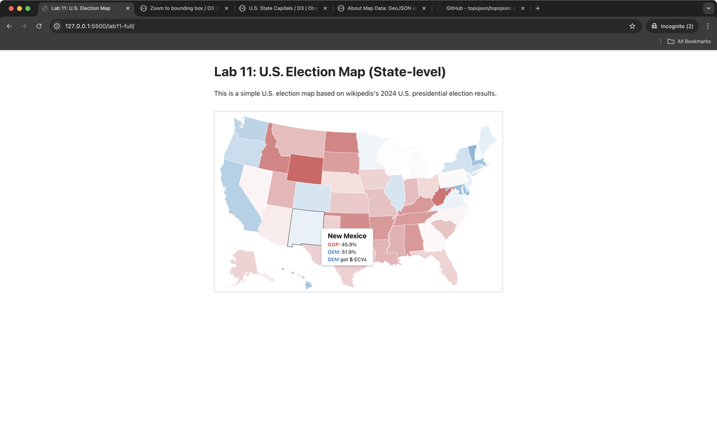

An colored map

You may notice some overlap in the borders (`stroke`) between states. Unfortunately, there’s no perfect fix for this in TopoJSON maps.

If it bothers you, one quick improvement is to **delete the following two blocks** (originally from the example):

```javascript
states.append("title")...   // optional tooltip-like titles
g.append("path")...         // draws white borders again
```

This reduces visual clutter slightly and avoids overlapping white lines.

## Part 4: Exercises (Required)

To complete this lab, make sure you finish the following:

- **Finish the tooltip**

  Your tooltip should appear when hovering over a state, and display:
  - State name
  - `republican_pct`
  - `democratic_pct`
- **Implement zoom**

  Restore and adapt the zoom functionality from the original example.  
  (Hint: Revisit the `zoom` and `clicked` blocks you commented out earlier. You may also need `reset` and `zoomed` blocks in the original example.)
- **Add padding around the map**

  Adjust the `viewBox` attribute in the SVG to give your map some breathing room.  
  (Hint: Make the width/height slightly larger or shift the x/y values inward.)

[figure not shown]

Lab 11: final demo

## Checklist✓

Map & election data loads without errors.  
All states visible on the map.  
No missing or incomplete state boundaries.  
States colored according to election results.  
Hover effect works on all states.  
Tooltip shows correct state information.  
Tooltip disappears on mouseout.  
You can zoom and drag the map.

## Submission process

- Raise your hand ✋
- Show the working webpage
- Demo the hover and zoom/drag
- Show your project structure in VS code; let us skim your `script.js`
- Any additional features implemented
- Confirm your name

## Troubleshooting

### Map not displaying

- Blank screen
- Partial map
- Console errors

**Solutions:** 1. Check data loading:

```javascript
console.log('Map data:', us_map);
console.log('Election data:', election_data);
```

2. Check path generator:

```javascript
console.log('Sample path:', path(states.features[0]));
```

### Incorrect colors

- Wrong party colors
- All states same color/no color

**Solutions:** 1. Check data merging:

```javascript
console.log('State data example:', states.features[0].properties.state_info);
```

2. Verify color scale:

```javascript
console.log('Color scale test:');
console.log('GOP +10:', colorScale({republican_pct: 55, democratic_pct: 45}));
console.log('DEM +10:', colorScale({republican_pct: 45, democratic_pct: 55}));
```

### Tooltip issues

- Tooltip not appearing
- Wrong position
- Missing information

**Solutions:** 1. Ensure you have “#tooltip” in your `index.html`

2. Verify mouse event data:

```javascript
.on("mouseover", function(event, d) {
    console.log('Mouse event:', event.pageX, event.pageY);
    console.log('State data:', d.properties.state_info);
});
```

3. Check CSS positioning:

```css
#tooltip {
    position: absolute;  /* Must be absolute */
    pointer-events: none;  /* Prevent tooltip interference */
}
```

### Data joining

- NaN values
- Undefined properties

**Solutions:** Check data structures:

```javascript
console.log('State IDs in map:', states_topo.features.map(d => d.id));
console.log('State IDs in election data:', election_data.map(d => d.id));
```

### Remember to:

- Use browser dev tools console for debugging
- Check network tab for data loading issues
- Verify file paths and permissions
- Test with sample data if real data fails